# Assignment 1

Group 8

2024-02-11

## R Markdown

We are hired as a Data Analyst to perform an analysis based on historical data. The key objective is to perform data analysis using R Programming.

This is the data set

```r
Life.Expectancy.Data <- read.csv("C:/Users/Turjo/OneDrive/Desktop/TRINA STUDY/Third Semester/4066 Analytics/Life Expectancy Data.csv")
```

Q1. Print the structure of your dataset

```r
str(Life.Expectancy.Data)
```

```
## 'data.frame':    2938 obs. of  22 variables:
##  $ Country                        : chr  "Afghanistan" "Afghanistan" "Afghanistan" "Afghanistan" ...
##  $ Year                           : int  2015 2014 2013 2012 2011 2010 2009 2008 2007 2006 ...
##  $ Status                         : chr  "Developing" "Developing" "Developing" "Developing" ...
##  $ Life.expectancy                : num  65 59.9 59.9 59.5 59.2 58.8 58.6 58.1 57.5 57.3 ...
##  $ Adult.Mortality                : int  263 271 268 272 275 279 281 287 295 295 ...
##  $ infant.deaths                  : int  62 64 66 69 71 74 77 80 82 84 ...
##  $ Alcohol                        : num  0.01 0.01 0.01 0.01 0.01 0.01 0.01 0.03 0.02 0.03 ...
##  $ percentage.expenditure         : num  71.3 73.5 73.2 78.2 7.1 ...
##  $ Hepatitis.B                    : int  65 62 64 67 68 66 63 64 63 64 ...
##  $ Measles                        : int  1154 492 430 2787 3013 1989 2861 1599 1141 1990 ...
##  $ BMI                            : num  19.1 18.6 18.1 17.6 17.2 16.7 16.2 15.7 15.2 14.7 ...
##  $ under.five.deaths              : int  83 86 89 93 97 102 106 110 113 116 ...
##  $ Polio                          : int  6 58 62 67 68 66 63 64 63 58 ...
##  $ Total.expenditure              : num  8.16 8.18 8.13 8.52 7.87 9.2 9.42 8.33 6.73 7.43 ...
##  $ Diphtheria                     : int  65 62 64 67 68 66 63 64 63 58 ...
##  $ HIV.AIDS                       : num  0.1 0.1 0.1 0.1 0.1 0.1 0.1 0.1 0.1 0.1 ...
##  $ GDP                            : num  584.3 612.7 631.7 670 63.5 ...
##  $ Population                     : num  33736494 327582 31731688 3696958 2978599 ...
##  $ thinness..1.19.years           : num  17.2 17.5 17.7 17.9 18.2 18.4 18.6 18.8 19 19.2 ...
##  $ thinness.5.9.years             : num  17.3 17.5 17.7 18 18.2 18.4 18.7 18.9 19.1 19.3 ...
##  $ Income.composition.of.resources: num  0.479 0.476 0.47 0.463 0.454 0.448 0.434 0.433 0.415 0.405 ...
##  $ Schooling                      : num  10.1 10 9.9 9.8 9.5 9.2 8.9 8.7 8.4 8.1 ...
```

Q2. List the variables in your dataset

```r
names(Life.Expectancy.Data)
```

```
##  [1] "Country"                         "Year"
##  [3] "Status"                          "Life.expectancy"
##  [5] "Adult.Mortality"                 "infant.deaths"
##  [7] "Alcohol"                         "percentage.expenditure"
##  [9] "Hepatitis.B"                     "Measles"
## [11] "BMI"                             "under.five.deaths"
## [13] "Polio"                           "Total.expenditure"
## [15] "Diphtheria"                      "HIV.AIDS"
## [17] "GDP"                             "Population"
## [19] "thinness..1.19.years"            "thinness.5.9.years"
## [21] "Income.composition.of.resources" "Schooling"
```

Q3. Print the top 15 rows of your dataset

```r
head(Life.Expectancy.Data, n = 15)
```

|  | Country | Year | Status | Life.expectancy | Adult.Mortality | infant.deaths | Alcohol | percentage.expenditure | Hepatitis.B | Measles | BMI | under.five.deaths | Polio | Total.expenditure | Diphtheria | HIV.AIDS | GDP | Population | thinness..1.19.years | thinness.5.9.years | Income.composition.of.resources | Schooling |
| --- | --- | --- | --- | --- | --- | --- | --- | --- | --- | --- | --- | --- | --- | --- | --- | --- | --- | --- | --- | --- | --- | --- |
| 1 | Afghanistan | 2015 | Developing | 65.0 | 263 | 62 | 0.01 | 71.279624 | 65 | 1154 | 19.1 | 83 | 6 | 8.16 | 65 | 0.1 | 584.25921 | 33736494 | 17.2 | 17.3 | 0.479 | 10.1 |
| 2 | Afghanistan | 2014 | Developing | 59.9 | 271 | 64 | 0.01 | 73.523582 | 62 | 492 | 18.6 | 86 | 58 | 8.18 | 62 | 0.1 | 612.69651 | 327582 | 17.5 | 17.5 | 0.476 | 10.0 |
| 3 | Afghanistan | 2013 | Developing | 59.9 | 268 | 66 | 0.01 | 73.219243 | 64 | 430 | 18.1 | 89 | 62 | 8.13 | 64 | 0.1 | 631.74498 | 31731688 | 17.7 | 17.7 | 0.470 | 9.9 |
| 4 | Afghanistan | 2012 | Developing | 59.5 | 272 | 69 | 0.01 | 78.184215 | 67 | 2787 | 17.6 | 93 | 67 | 8.52 | 67 | 0.1 | 669.95900 | 3696958 | 17.9 | 18.0 | 0.463 | 9.8 |
| 5 | Afghanistan | 2011 | Developing | 59.2 | 275 | 71 | 0.01 | 7.097109 | 68 | 3013 | 17.2 | 97 | 68 | 7.87 | 68 | 0.1 | 63.53723 | 2978599 | 18.2 | 18.2 | 0.454 | 9.5 |
| 6 | Afghanistan | 2010 | Developing | 58.8 | 279 | 74 | 0.01 | 79.679367 | 66 | 1989 | 16.7 | 102 | 66 | 9.20 | 66 | 0.1 | 553.32894 | 2883167 | 18.4 | 18.4 | 0.448 | 9.2 |
| 7 | Afghanistan | 2009 | Developing | 58.6 | 281 | 77 | 0.01 | 56.762217 | 63 | 2861 | 16.2 | 106 | 63 | 9.42 | 63 | 0.1 | 445.89330 | 284331 | 18.6 | 18.7 | 0.434 | 8.9 |
| 8 | Afghanistan | 2008 | Developing | 58.1 | 287 | 80 | 0.03 | 25.873925 | 64 | 1599 | 15.7 | 110 | 64 | 8.33 | 64 | 0.1 | 373.36112 | 2729431 | 18.8 | 18.9 | 0.433 | 8.7 |
| 9 | Afghanistan | 2007 | Developing | 57.5 | 295 | 82 | 0.02 | 10.910156 | 63 | 1141 | 15.2 | 113 | 63 | 6.73 | 63 | 0.1 | 369.83580 | 26616792 | 19.0 | 19.1 | 0.415 | 8.4 |
| 10 | Afghanistan | 2006 | Developing | 57.3 | 295 | 84 | 0.03 | 17.171518 | 64 | 1990 | 14.7 | 116 | 58 | 7.43 | 58 | 0.1 | 272.56377 | 2589345 | 19.2 | 19.3 | 0.405 | 8.1 |

[output cut: 5 more lines]

Q4. Write a user defined function using any of the variables from the data set.

```r
cube_alcohol = function(alcohol){alcohol^3}
cube_alcohol(Life.Expectancy.Data$Alcohol)
```

```
##    [1]    0.000001    0.000001    0.000001    0.000001    0.000001    0.000001
##    [7]    0.000001    0.000027    0.000008    0.000027    0.000008    0.000008
##   [13]    0.000001    0.000001    0.000001    0.000001   97.336000   91.733851
##   [19]  107.850176  135.796744  154.854153  147.197952  194.104539  176.558481
##   [25]  173.741112  149.721291  137.388096   93.576664   78.953589   51.895117
##   [31]   76.765625   49.027896          NA    0.000001    0.148877    0.287496
##   [37]    0.175616    0.091125    0.125000    0.097336    0.085184    0.046656
##   [43]    0.125000    0.091125    0.039304    0.046656    0.012167    0.015625
##   [49]          NA  578.009537  531.441000  559.476224  523.606616  474.552000
##   [55]  344.472101  353.393243  256.047875  199.176704  128.024064   43.986977
##   [61]   42.508549   22.425768   17.173512    6.331625          NA  627.222016
##   [67]  631.628712  547.343432  481.890304  481.890304  478.211768  565.609283
##   [73]  644.972544  712.121957  541.343375  385.828352  367.061696  374.805361
##   [79]  423.564751  384.240583          NA  498.677257  567.663552  582.182875
##   [85]  533.411731  541.343375  578.009537  594.823321  543.338496  465.484375
```

[output cut: 475 more lines]

Q5. Use data manipulation techniques and filter rows based on any logical criteria that exist in your dataset.

```r
library(tidyverse)
countryBD = as.data.frame(Life.Expectancy.Data %>% filter(Life.Expectancy.Data$Country == "Bangladesh"))
view(countryBD)
```

Q6. Identify the dependent & independent variables and use reshaping techniques and create a new data frame by joining those variables from your dataset.

```r
Newtable1 = cbind(Life.Expectancy.Data$Country, Life.Expectancy.Data$Status, Life.Expectancy.Data$Life.expectancy)
view(Newtable1)
Newtable3 = cbind(Life.Expectancy.Data$Country, Life.Expectancy.Data$infant.deaths, Life.Expectancy.Data$GDP, Life.Expectancy.Data$Population)
view(Newtable3)
Totaltable = merge(Newtable1, Newtable3, by = "V1")
view(Totaltable)
```

Q7. Remove missing values in your dataset.

```r
Life.Expectancy.Data = as.data.frame(na.omit(Life.Expectancy.Data))
```

Q8. Identify and remove duplicated data in your dataset

```r
lifex = as.data.frame(Life.Expectancy.Data %>% distinct(GDP, .keep_all = TRUE) )
```

Q9. Reorder multiple rows in descending order

```r
lifex2 = as.data.frame(Life.Expectancy.Data %>% arrange( desc(Year)))
```

Q10. Rename some of the column names in your dataset

```r
names(Life.Expectancy.Data)[4]= "Life Expectency"
names(Life.Expectancy.Data)[5] = "Adult Mortality"
names(Life.Expectancy.Data)[6] = "Infant Deaths"
```

Q11. Add new variables in your data frame by using a mathematical function (for e.g. – multiply an existing column by 2 and add it as a new variable to your data frame)

```r
Life.Expectancy.Data = as.data.frame(Life.Expectancy.Data %>% mutate( Double.Schooling = Life.Expectancy.Data$Schooling * 2))
```

Q12. Create a training set using random number generator engine.

```r
lifex3 = cbind(Life.Expectancy.Data$Country, Life.Expectancy.Data$Year, Life.Expectancy.Data$Status, Life.Expectancy.Data$`Life Expectency`, Life.Expectancy.Data$`Adult Mortality`)
lifex3 = as.data.frame(lifex3)
set.seed(1234)
lifex3 = as.data.frame(lifex3 %>% sample_frac(0.8, replace = FALSE) )
view(lifex3)
```

Q13. Print the summary statistics of your dataset

```r
summary(Life.Expectancy.Data)
```

```
##    Country               Year         Status          Life Expectency
##  Length:1649        Min.   :2000   Length:1649        Min.   :44.0
##  Class :character   1st Qu.:2005   Class :character   1st Qu.:64.4
##  Mode  :character   Median :2008   Mode  :character   Median :71.7
##                     Mean   :2008                      Mean   :69.3
##                     3rd Qu.:2011                      3rd Qu.:75.0
##                     Max.   :2015                      Max.   :89.0
##  Adult Mortality Infant Deaths        Alcohol       percentage.expenditure
##  Min.   :  1.0   Min.   :   0.00   Min.   : 0.010   Min.   :    0.00
##  1st Qu.: 77.0   1st Qu.:   1.00   1st Qu.: 0.810   1st Qu.:   37.44
##  Median :148.0   Median :   3.00   Median : 3.790   Median :  145.10
##  Mean   :168.2   Mean   :  32.55   Mean   : 4.533   Mean   :  698.97
##  3rd Qu.:227.0   3rd Qu.:  22.00   3rd Qu.: 7.340   3rd Qu.:  509.39
##  Max.   :723.0   Max.   :1600.00   Max.   :17.870   Max.   :18961.35
##   Hepatitis.B       Measles            BMI        under.five.deaths
##  Min.   : 2.00   Min.   :     0   Min.   : 2.00   Min.   :   0.00
##  1st Qu.:74.00   1st Qu.:     0   1st Qu.:19.50   1st Qu.:   1.00
##  Median :89.00   Median :    15   Median :43.70   Median :   4.00
##  Mean   :79.22   Mean   :  2224   Mean   :38.13   Mean   :  44.22
##  3rd Qu.:96.00   3rd Qu.:   373   3rd Qu.:55.80   3rd Qu.:  29.00
##  Max.   :99.00   Max.   :131441   Max.   :77.10   Max.   :2100.00
##      Polio       Total.expenditure   Diphtheria       HIV.AIDS
##  Min.   : 3.00   Min.   : 0.740    Min.   : 2.00   Min.   : 0.100
##  1st Qu.:81.00   1st Qu.: 4.410    1st Qu.:82.00   1st Qu.: 0.100
##  Median :93.00   Median : 5.840    Median :92.00   Median : 0.100
##  Mean   :83.56   Mean   : 5.956    Mean   :84.16   Mean   : 1.984
##  3rd Qu.:97.00   3rd Qu.: 7.470    3rd Qu.:97.00   3rd Qu.: 0.700
##  Max.   :99.00   Max.   :14.390    Max.   :99.00   Max.   :50.600
##       GDP              Population        thinness..1.19.years
##  Min.   :     1.68   Min.   :3.400e+01   Min.   : 0.100
##  1st Qu.:   462.15   1st Qu.:1.919e+05   1st Qu.: 1.600
##  Median :  1592.57   Median :1.420e+06   Median : 3.000
##  Mean   :  5566.03   Mean   :1.465e+07   Mean   : 4.851
##  3rd Qu.:  4718.51   3rd Qu.:7.659e+06   3rd Qu.: 7.100
##  Max.   :119172.74   Max.   :1.294e+09   Max.   :27.200
##  thinness.5.9.years Income.composition.of.resources   Schooling
##  Min.   : 0.100     Min.   :0.0000                  Min.   : 4.20
##  1st Qu.: 1.700     1st Qu.:0.5090                  1st Qu.:10.30
##  Median : 3.200     Median :0.6730                  Median :12.30
##  Mean   : 4.908     Mean   :0.6316                  Mean   :12.12
##  3rd Qu.: 7.100     3rd Qu.:0.7510                  3rd Qu.:14.00
##  Max.   :28.200     Max.   :0.9360                  Max.   :20.70
##  Double.Schooling
##  Min.   : 8.40
##  1st Qu.:20.60
##  Median :24.60
##  Mean   :24.24
##  3rd Qu.:28.00
##  Max.   :41.40
```

Q14. Use any of the numerical variables from the dataset and perform the following statistical functions

Mean

```r
mean(Life.Expectancy.Data$`Life Expectency`)
```

```
## [1] 69.3023
```

Median

```r
median(Life.Expectancy.Data$`Life Expectency`)
```

```
## [1] 71.7
```

```r
mode(Life.Expectancy.Data$`Life Expectency`)
```

```
## [1] "numeric"
```

Range

```r
range(Life.Expectancy.Data$`Life Expectency`)
```

```
## [1] 44 89
```

Q15. Plot a scatter plot for any 2 variables in your dataset

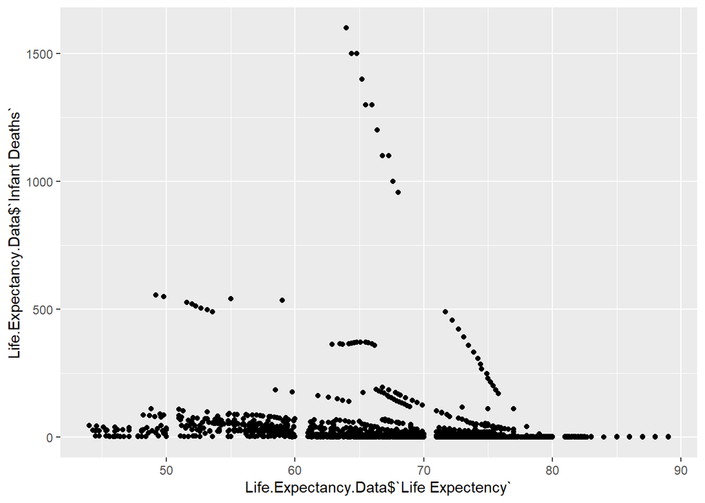

```r
ggplot(data = Life.Expectancy.Data, aes( x = Life.Expectancy.Data$`Life Expectency`, y = Life.Expectancy.Data$`Infant Deaths`)) + geom_point()
```

Q16. Plot a bar plot for any 2 variables in your dataset

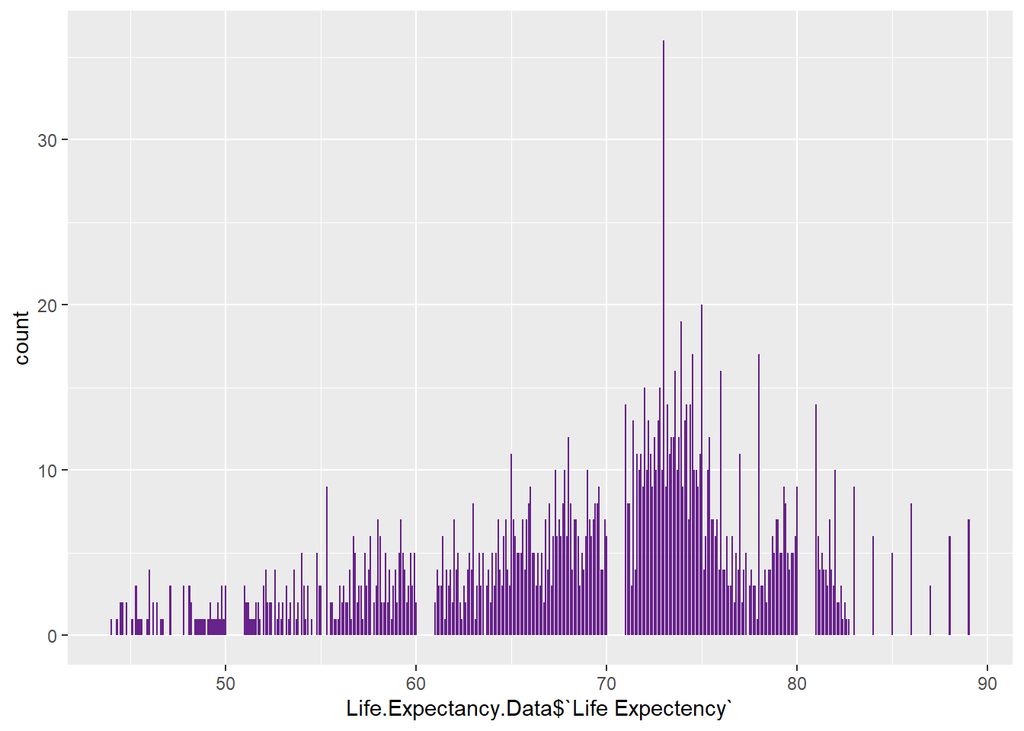

```r
ggplot(Life.Expectancy.Data, aes(x = Life.Expectancy.Data$`Life Expectency`))+ geom_bar(fill = "darkorchid4")
```

Q17. Find the correlation between any 2 variables by applying least square linear regression mode

```r
lifeexCorr = cor(Life.Expectancy.Data$percentage.expenditure, Life.Expectancy.Data$GDP, method = "pearson")
lifeexCorr
```

```
## [1] 0.9592989
```

Link to GIT Repository

https://github.com/AnikaTrina/Trina